# BDM Group 10–Heart Failure Prediction

BDM Group 10–Abhishek, Mohan, Yimeng, Yuxi, Pengqi, Oisin

2023-11-29

# 1 Introduction

This is used to predict mortality by heart failure, and the data set including 12 features

In this analysis, different features were first visualized, followed by correlation analysis. After dividing the training and testing sets of the dataset, SVM, KNN, LR, RFM, DT, and XGBoost models are used for analysis and prediction. And compare their accuracy to select the best model. At the same time, analyze the influencing factors of the main effective models based on the results. Finally, using standardized data, conduct model testing and accuracy comparison to determine the most suitable model.

# 2 Setup

## 2.1 Load libraries

```r
library(tidyverse)  # Data manipulation and visualization
library(corrplot)   # Visualization of correlation matrix
library(kernlab)    # Support Vector Machines (SVM)
library(pROC)       # ROC curve analysis
library(rpart)      # Decision Trees
library(rpart.plot) # Plotting decision trees
library(class)      # k-Nearest Neighbors (kNN)
library(gmodels)    # CrossTable for kNN evaluation
library(keras)      # Deep Learning with Keras
library(randomForest) # Random Forest
library(caret)      # Confusion matrix for Random Forest
library(xgboost)    # XGBoost for gradient boosting
library(GGally)
library(kableExtra)
library(viridis) #colour pallet
library(patchwork) #combine plots
library(ggplot2)
```

## 2.2 Load data

```r
# library(tidyverse)
ROOT = "heart_failure_clinical_records_dataset"
palette_ro = c("#ee2f35", "#fa7211", "#fbd600", "#75c731", "#1fb86e", "#0488cf", "#7b44ab")

df <- read.csv("heart_failure_clinical_records_dataset.csv")
data <- read.csv("heart_failure_clinical_records_dataset.csv")
f_features = c("anaemia", "diabetes", "high_blood_pressure", "sex", "smoking", "DEATH_EVENT")

df_n <- df
df <- df %>%
  mutate_at(f_features, as.factor)
```

# 3 Check data

Dataset from: [Machine learning can predict survival of patients with heart failure from serum creatinine and ejection fraction alone](https://bmcmedinformdecismak.biomedcentral.com/articles/10.1186/s12911-020-1023-5)

## 3.1 Dataset

```r
# Display the first few rows of the data and a summary
data %>% head()
```

|  | age | anaemia | creatinine_phosphokinase | diabetes | ejection_fraction | high_blood_pressure | platelets | serum_creatinine | serum_sodium | sex | smoking | time | DEATH_EVENT |
| --- | --- | --- | --- | --- | --- | --- | --- | --- | --- | --- | --- | --- | --- |
| 1 | 75 | 0 | 582 | 0 | 20 | 1 | 265000 | 1.9 | 130 | 1 | 0 | 4 | 1 |
| 2 | 55 | 0 | 7861 | 0 | 38 | 0 | 263358 | 1.1 | 136 | 1 | 0 | 6 | 1 |
| 3 | 65 | 0 | 146 | 0 | 20 | 0 | 162000 | 1.3 | 129 | 1 | 1 | 7 | 1 |
| 4 | 50 | 1 | 111 | 0 | 20 | 0 | 210000 | 1.9 | 137 | 1 | 0 | 7 | 1 |
| 5 | 65 | 1 | 160 | 1 | 20 | 0 | 327000 | 2.7 | 116 | 0 | 0 | 8 | 1 |
| 6 | 90 | 1 | 47 | 0 | 40 | 1 | 204000 | 2.1 | 132 | 1 | 1 | 8 | 1 |

```r
summary(data)
```

```
##       age           anaemia       creatinine_phosphokinase    diabetes
##  Min.   :40.00   Min.   :0.0000   Min.   :  23.0           Min.   :0.0000
##  1st Qu.:51.00   1st Qu.:0.0000   1st Qu.: 116.5           1st Qu.:0.0000
##  Median :60.00   Median :0.0000   Median : 250.0           Median :0.0000
##  Mean   :60.83   Mean   :0.4314   Mean   : 581.8           Mean   :0.4181
##  3rd Qu.:70.00   3rd Qu.:1.0000   3rd Qu.: 582.0           3rd Qu.:1.0000
##  Max.   :95.00   Max.   :1.0000   Max.   :7861.0           Max.   :1.0000
##  ejection_fraction high_blood_pressure   platelets      serum_creatinine
##  Min.   :14.00     Min.   :0.0000      Min.   : 25100   Min.   :0.500
##  1st Qu.:30.00     1st Qu.:0.0000      1st Qu.:212500   1st Qu.:0.900
##  Median :38.00     Median :0.0000      Median :262000   Median :1.100
##  Mean   :38.08     Mean   :0.3512      Mean   :263358   Mean   :1.394
##  3rd Qu.:45.00     3rd Qu.:1.0000      3rd Qu.:303500   3rd Qu.:1.400
##  Max.   :80.00     Max.   :1.0000      Max.   :850000   Max.   :9.400
##   serum_sodium        sex            smoking            time
##  Min.   :113.0   Min.   :0.0000   Min.   :0.0000   Min.   :  4.0
##  1st Qu.:134.0   1st Qu.:0.0000   1st Qu.:0.0000   1st Qu.: 73.0
##  Median :137.0   Median :1.0000   Median :0.0000   Median :115.0
##  Mean   :136.6   Mean   :0.6488   Mean   :0.3211   Mean   :130.3
##  3rd Qu.:140.0   3rd Qu.:1.0000   3rd Qu.:1.0000   3rd Qu.:203.0
##  Max.   :148.0   Max.   :1.0000   Max.   :1.0000   Max.   :285.0
##   DEATH_EVENT
##  Min.   :0.0000
##  1st Qu.:0.0000
##  Median :0.0000
##  Mean   :0.3211
##  3rd Qu.:1.0000
##  Max.   :1.0000
```

## 3.2 Explanation of variables

- `age` - Age
- `anaemia` - Decrease of red blood cells or hemoglobin (boolean) (0:`False`, 1:`True`)
- `creatinine_phosphokinase` - Level of the CPK enzyme in the blood (mcg/L)
- `diabetes` - If the patient has diabetes (boolean) (0:`False`, 1:`True`)
- `ejection_fraction` - Percentage of blood leaving the heart at each contraction (percentage)
- `high_blood_pressure` - If the patient has hypertension (boolean) (0:`False`, 1:`True`)
- `platelets` - Platelets in the blood (kiloplatelets/mL)
- `serum_creatinine` - Level of serum creatinine in the blood (mg/dL)
- `serum_sodium` - Level of serum sodium in the blood (mEq/L)
- `sex` - Woman or man (binary) (0: Woman, 1: Man)
- `smoking` - If the patient smokes or not (boolean) (0:`False`, 1:`True`)
- `time` - Follow-up period (days)
- `DEATH_EVENT` - If the patient deceased during the follow-up period (boolean)

## 3.3 Data size and structure

```r
# Display the first few rows of the data and a summary
data %>% head()
```

|  | age | anaemia | creatinine_phosphokinase | diabetes | ejection_fraction | high_blood_pressure | platelets | serum_creatinine | serum_sodium | sex | smoking | time | DEATH_EVENT |
| --- | --- | --- | --- | --- | --- | --- | --- | --- | --- | --- | --- | --- | --- |
| 1 | 75 | 0 | 582 | 0 | 20 | 1 | 265000 | 1.9 | 130 | 1 | 0 | 4 | 1 |
| 2 | 55 | 0 | 7861 | 0 | 38 | 0 | 263358 | 1.1 | 136 | 1 | 0 | 6 | 1 |
| 3 | 65 | 0 | 146 | 0 | 20 | 0 | 162000 | 1.3 | 129 | 1 | 1 | 7 | 1 |
| 4 | 50 | 1 | 111 | 0 | 20 | 0 | 210000 | 1.9 | 137 | 1 | 0 | 7 | 1 |
| 5 | 65 | 1 | 160 | 1 | 20 | 0 | 327000 | 2.7 | 116 | 0 | 0 | 8 | 1 |
| 6 | 90 | 1 | 47 | 0 | 40 | 1 | 204000 | 2.1 | 132 | 1 | 1 | 8 | 1 |

## 3.4 Data summary

```r
# Display the first few rows of the data and a summary
summary(data)
```

```
##       age           anaemia       creatinine_phosphokinase    diabetes
##  Min.   :40.00   Min.   :0.0000   Min.   :  23.0           Min.   :0.0000
##  1st Qu.:51.00   1st Qu.:0.0000   1st Qu.: 116.5           1st Qu.:0.0000
##  Median :60.00   Median :0.0000   Median : 250.0           Median :0.0000
##  Mean   :60.83   Mean   :0.4314   Mean   : 581.8           Mean   :0.4181
##  3rd Qu.:70.00   3rd Qu.:1.0000   3rd Qu.: 582.0           3rd Qu.:1.0000
##  Max.   :95.00   Max.   :1.0000   Max.   :7861.0           Max.   :1.0000
##  ejection_fraction high_blood_pressure   platelets      serum_creatinine
##  Min.   :14.00     Min.   :0.0000      Min.   : 25100   Min.   :0.500
##  1st Qu.:30.00     1st Qu.:0.0000      1st Qu.:212500   1st Qu.:0.900
##  Median :38.00     Median :0.0000      Median :262000   Median :1.100
##  Mean   :38.08     Mean   :0.3512      Mean   :263358   Mean   :1.394
##  3rd Qu.:45.00     3rd Qu.:1.0000      3rd Qu.:303500   3rd Qu.:1.400
##  Max.   :80.00     Max.   :1.0000      Max.   :850000   Max.   :9.400
##   serum_sodium        sex            smoking            time
##  Min.   :113.0   Min.   :0.0000   Min.   :0.0000   Min.   :  4.0
##  1st Qu.:134.0   1st Qu.:0.0000   1st Qu.:0.0000   1st Qu.: 73.0
##  Median :137.0   Median :1.0000   Median :0.0000   Median :115.0
##  Mean   :136.6   Mean   :0.6488   Mean   :0.3211   Mean   :130.3
##  3rd Qu.:140.0   3rd Qu.:1.0000   3rd Qu.:1.0000   3rd Qu.:203.0
##  Max.   :148.0   Max.   :1.0000   Max.   :1.0000   Max.   :285.0
##   DEATH_EVENT
##  Min.   :0.0000
##  1st Qu.:0.0000
##  Median :0.0000
##  Mean   :0.3211
##  3rd Qu.:1.0000
##  Max.   :1.0000
```

# 4 Data visualizations

Use data visualization to fast look data.

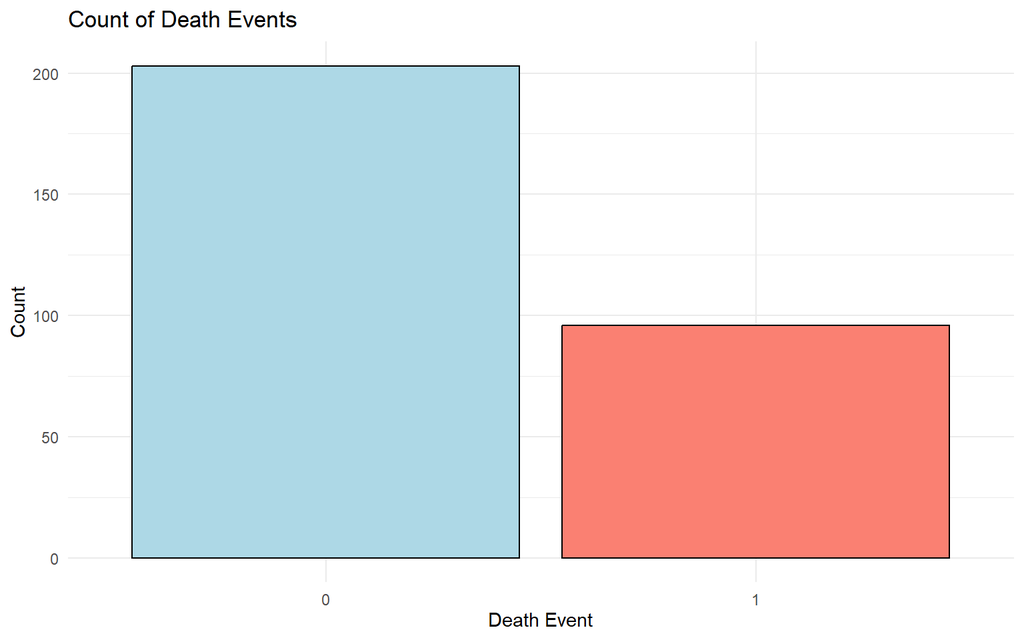

```r
# Create a bar plot showing the count of Death events
ggplot(data, aes(x = factor(DEATH_EVENT), fill = factor(DEATH_EVENT))) +
  geom_bar(color = "black", fill = c("lightblue", "salmon"), position = "identity") +
  theme_minimal() +
  labs(title = 'Count of Death Events', x = 'Death Event', y = 'Count') +
  scale_fill_manual(values = c("lightblue", "salmon")) +
  theme(axis.text.x = element_text(angle = 0, hjust = 0.5, vjust = 0.5))
```

## 4.1 Distribution of the binary features

### 4.1.1 Features vs target (count)

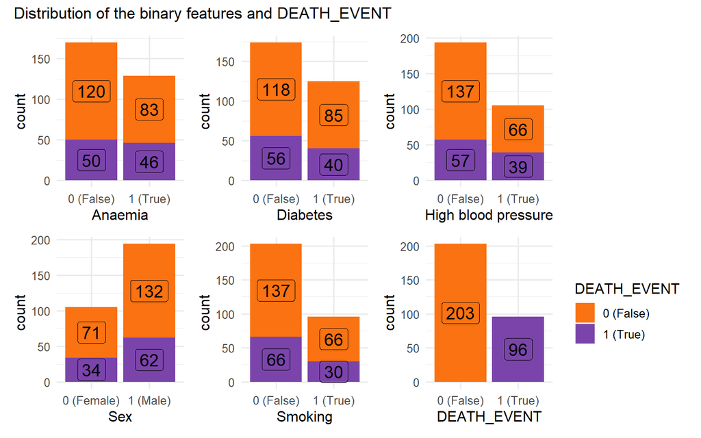

Fig. 1

```r
# Plot for Anaemia
p1 <- ggplot(df, aes(x = anaemia, fill = DEATH_EVENT)) +
  geom_bar(stat = "count", position = "stack", show.legend = FALSE) +
  scale_x_discrete(labels  = c("0 (False)", "1 (True)")) +
  scale_fill_manual(values = c(palette_ro[2], palette_ro[7]),
                    name = "DEATH_EVENT",
                    labels = c("0 (False)", "1 (True)")) +
  labs(x = "Anaemia") +
  theme_minimal(base_size = 12) +
  geom_label(stat = "count", aes(label = ..count..), position = position_stack(vjust = 0.5),
             size = 5, show.legend = FALSE)

# Plot for Diabetes
p2 <- ggplot(df, aes(x = diabetes, fill = DEATH_EVENT)) +
  geom_bar(stat = "count", position = "stack", show.legend = FALSE) +
  scale_x_discrete(labels  = c("0 (False)", "1 (True)")) +
  scale_fill_manual(values = c(palette_ro[2], palette_ro[7]),
                    name = "DEATH_EVENT",
                    labels = c("0 (False)", "1 (True)")) +
  labs(x = "Diabetes") +
  theme_minimal(base_size = 12) +
  geom_label(stat = "count", aes(label = ..count..), position = position_stack(vjust = 0.5),
             size = 5, show.legend = FALSE)

# Plot for High Blood Pressure
p3 <- ggplot(df, aes(x = high_blood_pressure, fill = DEATH_EVENT)) +
  geom_bar(stat = "count", position = "stack", show.legend = FALSE) +
  scale_x_discrete(labels  = c("0 (False)", "1 (True)")) +
  scale_fill_manual(values = c(palette_ro[2], palette_ro[7]),
                    name = "DEATH_EVENT",
                    labels = c("0 (False)", "1 (True)")) +
  labs(x = "High blood pressure") +
  theme_minimal(base_size = 12) +
  geom_label(stat = "count", aes(label = ..count..), position = position_stack(vjust = 0.5),
             size = 5, show.legend = FALSE)

# Plot for Sex
p4 <- ggplot(df, aes(x = sex, fill = DEATH_EVENT)) +
  geom_bar(stat = "count", position = "stack", show.legend = FALSE) +
  scale_x_discrete(labels  = c("0 (Female)", "1 (Male)")) +
  scale_fill_manual(values = c(palette_ro[2], palette_ro[7]),
                    name = "DEATH_EVENT",
                    labels = c("0 (False)", "1 (True)")) +
  labs(x = "Sex") +
  theme_minimal(base_size = 12) +
  geom_label(stat = "count", aes(label= ..count..), position = position_stack(vjust = 0.5),
             size = 5, show.legend = FALSE)

# Plot for Smoking
p5 <- ggplot(df, aes(x = smoking, fill = DEATH_EVENT)) +
  geom_bar(stat = "count", position = "stack", show.legend = FALSE) +
  scale_x_discrete(labels  = c("0 (False)", "1 (True)")) +
  scale_fill_manual(values = c(palette_ro[2], palette_ro[7]),
                    name = "DEATH_EVENT",
                    labels = c("0 (False)", "1 (True)")) +
  labs(x = "Smoking") +
  theme_minimal(base_size = 12) +
  geom_label(stat = "count", aes(label = ..count..), position = position_stack(vjust = 0.5),
             size = 5, show.legend = FALSE)

# Plot for DEATH_EVENT
p6 <- ggplot(df, aes(x = DEATH_EVENT, fill = DEATH_EVENT)) +
  geom_bar(stat = "count", position = "stack", show.legend = TRUE) +
  scale_x_discrete(labels  = c("0 (False)", "1 (True)")) +
  scale_fill_manual(values = c(palette_ro[2], palette_ro[7]),
                    name = "DEATH_EVENT",
                    labels = c("0 (False)", "1 (True)")) +
  labs(x = "DEATH_EVENT") +
  theme_minimal(base_size = 12) +
  geom_label(stat = "count", aes(label = ..count..), position = position_stack(vjust = 0.5),
             size = 5, show.legend = FALSE)

# Combine plots into a layout
combined_plot <- ((p1 + p2 + p3) / (p4 + p5 + p6)) +
  plot_annotation(title = "Distribution of the binary features and DEATH_EVENT")

# Display the combined plot
print(combined_plot)
```

Insights:

- The objective variable are not distribute averagem.

### 4.1.2 Features vs target (percentage)

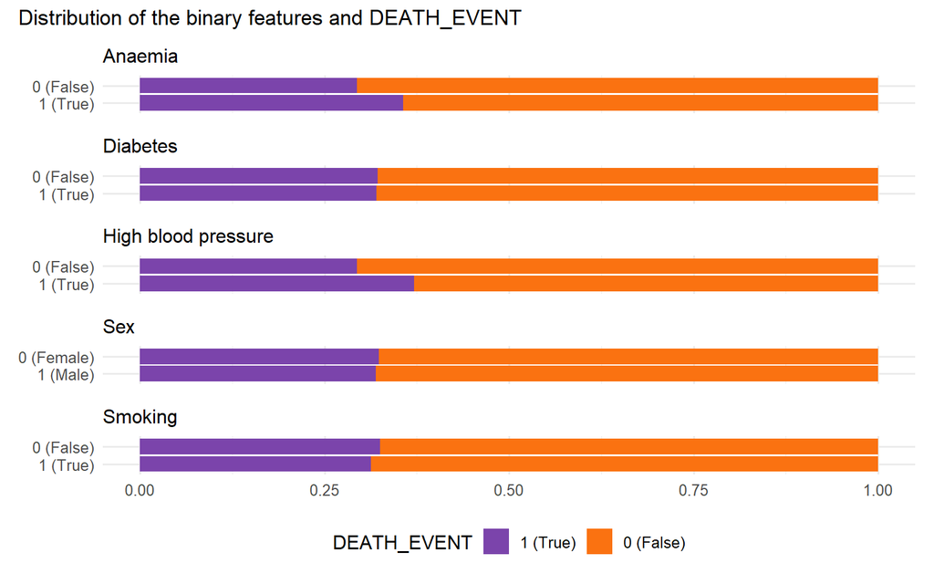

Fig. 2

```r
# Plot for Anaemia
p1 <- ggplot(df, aes(y = reorder(anaemia, as.numeric(anaemia) * -1), fill = DEATH_EVENT)) +
  geom_bar(position = "fill", show.legend = FALSE) +
  scale_y_discrete(labels  = c("1 (True)", "0 (False)")) +
  scale_fill_manual(values = c(palette_ro[2], palette_ro[7]),
                    name = "DEATH_EVENT",
                    labels = c("0 (False)", "1 (True)")) +
  labs(subtitle = "Anaemia") +
  theme_minimal(base_size = 12) +
  theme(axis.title = element_blank(), axis.text.x = element_blank())

# Plot for Diabetes
p2 <- ggplot(df, aes(y = reorder(diabetes, as.numeric(diabetes) * -1), fill = DEATH_EVENT)) +
  geom_bar(position = "fill", show.legend = FALSE) +
  scale_y_discrete(labels  = c("1 (True)", "0 (False)")) +
  scale_fill_manual(values = c(palette_ro[2], palette_ro[7]),
                    name = "DEATH_EVENT",
                    labels = c("0 (False)", "1 (True)")) +
  labs(subtitle = "Diabetes") +
  theme_minimal(base_size = 12) +
  theme(axis.title = element_blank(), axis.text.x = element_blank())

# Plot for High Blood Pressure
p3 <- ggplot(df, aes(y = reorder(high_blood_pressure, as.numeric(high_blood_pressure) * -1), fill = DEATH_EVENT)) +
  geom_bar(position = "fill", show.legend = FALSE) +
  scale_y_discrete(labels  = c("1 (True)", "0 (False)")) +
  scale_fill_manual(values = c(palette_ro[2], palette_ro[7]),
                    name = "DEATH_EVENT",
                    labels = c("0 (False)", "1 (True)")) +
  labs(subtitle = "High blood pressure") +
  theme_minimal(base_size = 12) +
  theme(axis.title = element_blank(), axis.text.x = element_blank())

# Plot for Sex
p4 <- ggplot(df, aes(y = reorder(sex, as.numeric(sex) * -1), fill = DEATH_EVENT)) +
  geom_bar(position = "fill", show.legend = FALSE) +
  scale_y_discrete(labels  = c("1 (Male)", "0 (Female)")) +
  scale_fill_manual(values = c(palette_ro[2], palette_ro[7]),
                    name = "DEATH_EVENT",
                    labels = c("0 (False)", "1 (True)")) +
  labs(subtitle = "Sex") +
  theme_minimal(base_size = 12) +
  theme(axis.title = element_blank(), axis.text.x = element_blank())

# Plot for Smoking
p5 <- ggplot(df, aes(y = reorder(smoking, as.numeric(smoking) * -1), fill = DEATH_EVENT)) +
  geom_bar(position = "fill", show.legend = TRUE) +
  scale_y_discrete(labels  = c("1 (True)", "0 (False)")) +
  scale_fill_manual(values = c(palette_ro[2], palette_ro[7]),
                    name = "DEATH_EVENT",
                    labels = c("0 (False)", "1 (True)")) +
  labs(subtitle = "Smoking") +
  theme_minimal(base_size = 12) +
  theme(axis.title = element_blank(), legend.position = "bottom", legend.direction = "horizontal") +
  guides(fill = guide_legend(reverse = TRUE))

# Combine plots into a layout
combined_plot <- (p1 + p2 + p3 + p4 + p5 + plot_layout(ncol = 1)) +
  plot_annotation(title = "Distribution of the binary features and DEATH_EVENT")

# Display the combined plot
print(combined_plot)
```

Insights:

The probability of death distribution in diamonds, Sex, and Somking is similar, while the probability of death distribution in Anaemia and High blood pressure is different. We can speculate that there is a certain influence relationship between them, but further proof is needed.

## 4.2 Correlation matrix

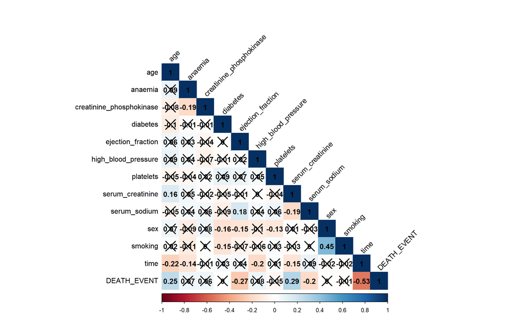

Fig. 11

```r
# corelation matrix (p-value) below 0.05 are marked with a cross
cor(df_n) %>%
  corrplot(method = "color", type = "lower", tl.col = "black", tl.srt = 45,
           addCoef.col = TRUE,
           p.mat = cor.mtest(df_n)$p,
           sig.level = 0.05)
```

Use correlation coefficients to draw the Correlation matrix.

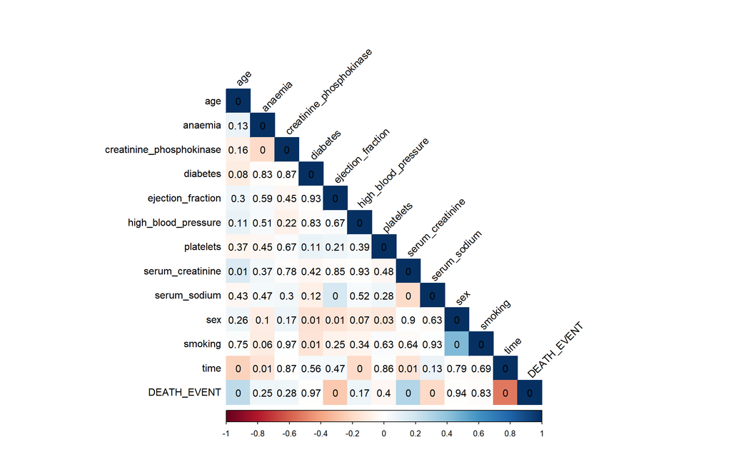

Fig. 12

```r
#  p-values are shown instead of the correlation coefficients.
cor(df_n) %>%
  corrplot(method = "color", type = "lower", tl.col = "black", tl.srt = 45,
           p.mat = cor.mtest(df_n)$p,
           insig = "p-value", sig.level = -1)
```

Insights:

- `time`, `serum_creatinine`, `ejection_fraction`, `age`, and `serum_creatinine` are relative significant variables.

## 4.3 Distribution of Numeric features

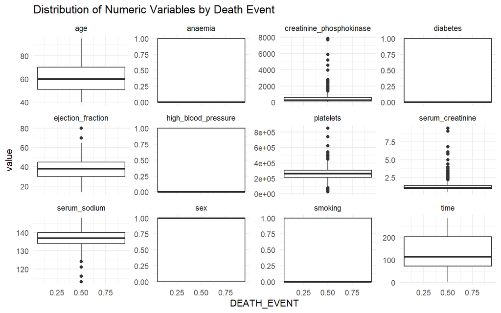

```r
# Boxplot for numeric variables
numeric_vars <- select_if(data, is.numeric)
numeric_vars_long <- pivot_longer(numeric_vars, cols = -c(DEATH_EVENT))

ggplot(numeric_vars_long, aes(x = DEATH_EVENT, y = value, fill = DEATH_EVENT)) +
  geom_boxplot() +
  facet_wrap(~name, scales = "free_y") +
  theme_minimal() +
  labs(title = 'Distribution of Numeric Variables by Death Event')
```

### 4.3.2 Correlation heatmap for numeric variables

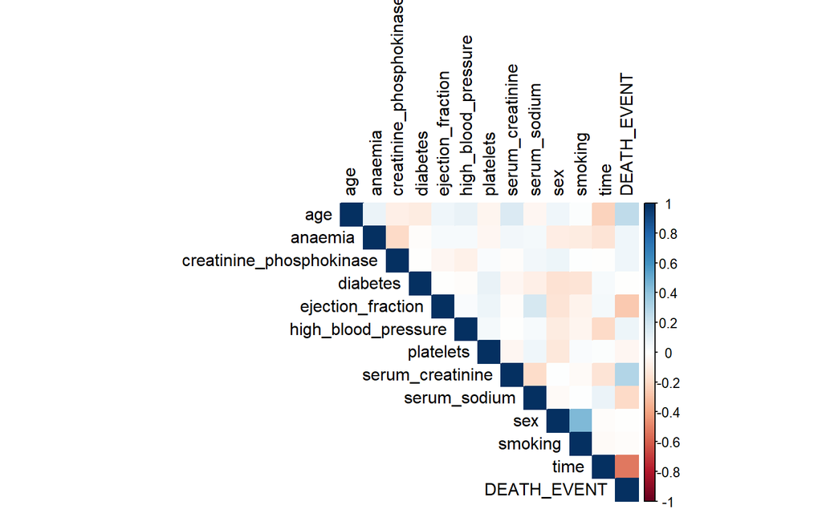

```r
# Correlation heatmap for numeric variables
numeric_cor <- cor(numeric_vars)
corrplot(numeric_cor, method = 'color', type = 'upper', tl.col = 'black')
```

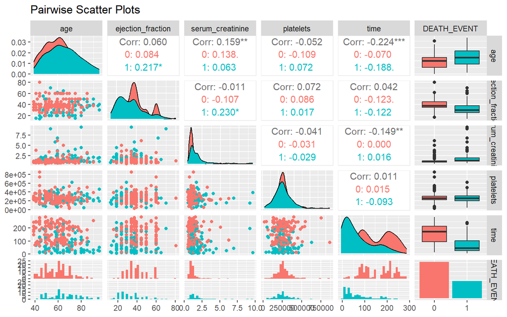

```r
# pariwise scatter plot graph
data$DEATH_EVENT <- as.factor(data$DEATH_EVENT)
ggpairs(data, columns = c("age", "ejection_fraction", "serum_creatinine", "platelets", "time", "DEATH_EVENT"),
        mapping = aes(color = DEATH_EVENT),
        title = 'Pairwise Scatter Plots')
```

### 4.3.4 Additional summary statistics

```r
# Additional summary statistics
summary_stats <- summary(data)
summary_table <- knitr::kable(summary_stats, format = "html") %>%
  kable_styling()

# Display the summary statistics table
cat(summary_table)
```

[output not shown]

[output cut: 63 more lines]

[output not shown]

### 4.3.5 Mean again Further analysis:

```r
# Convert DEATH_EVENT to a factor for further analysis
data$DEATH_EVENT <- as.factor(data$DEATH_EVENT)

# Further analysis: calculating mean values for death and not death events
death_data <- filter(data, DEATH_EVENT == 1)
notdeath_data <- filter(data, DEATH_EVENT == 0)
mean_death_data <- list()
mean_notdeath_data <- list()
clst <- list()

# Loop through columns and calculate mean values
for (i in 2:ncol(data) - 1) {
  a <- sum(death_data[[i]]) / nrow(death_data[i])
  mean_death_data <- append(mean_death_data, a)
  b <- sum(notdeath_data[[i]]) / nrow(notdeath_data[i])
  mean_notdeath_data <- append(mean_notdeath_data, b)
  clst <- append(clst, names(data[i]))
}
mean_data <- as.matrix(rbind(clst, mean_death_data, mean_notdeath_data))
mean_data
```

```
##                    [,1]     [,2]      [,3]                       [,4]
## clst               "age"    "anaemia" "creatinine_phosphokinase" "diabetes"
## mean_death_data    65.21528 0.4791667 670.1979                   0.4166667
## mean_notdeath_data 58.76191 0.408867  540.0542                   0.4187192
##                    [,5]                [,6]                  [,7]
## clst               "ejection_fraction" "high_blood_pressure" "platelets"
## mean_death_data    33.46875            0.40625               256381
## mean_notdeath_data 40.26601            0.3251232             266657.5
##                    [,8]               [,9]           [,10]     [,11]
## clst               "serum_creatinine" "serum_sodium" "sex"     "smoking"
## mean_death_data    1.835833           135.375        0.6458333 0.3125
## mean_notdeath_data 1.184877           137.2167       0.6502463 0.3251232
##                    [,12]
## clst               "time"
## mean_death_data    70.88542
## mean_notdeath_data 158.3399
```

## 4.4 Selected variables

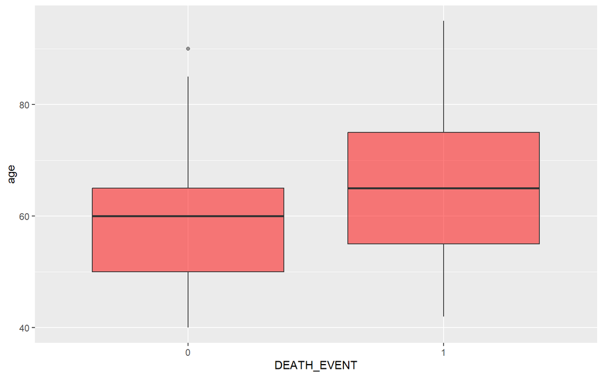

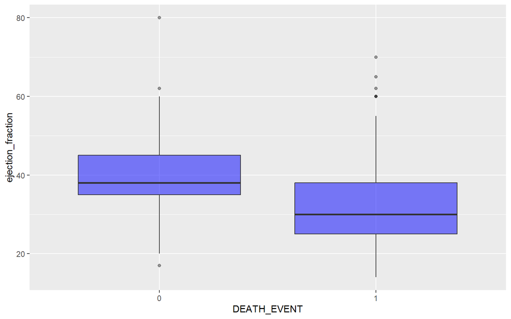

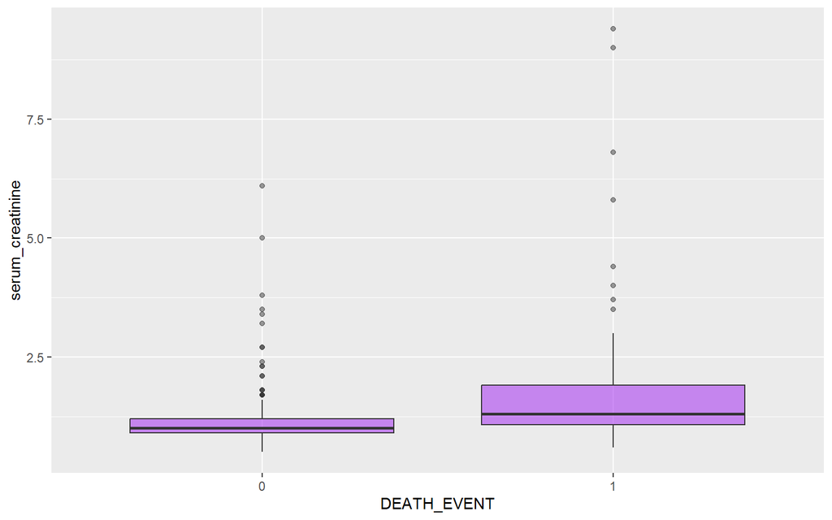

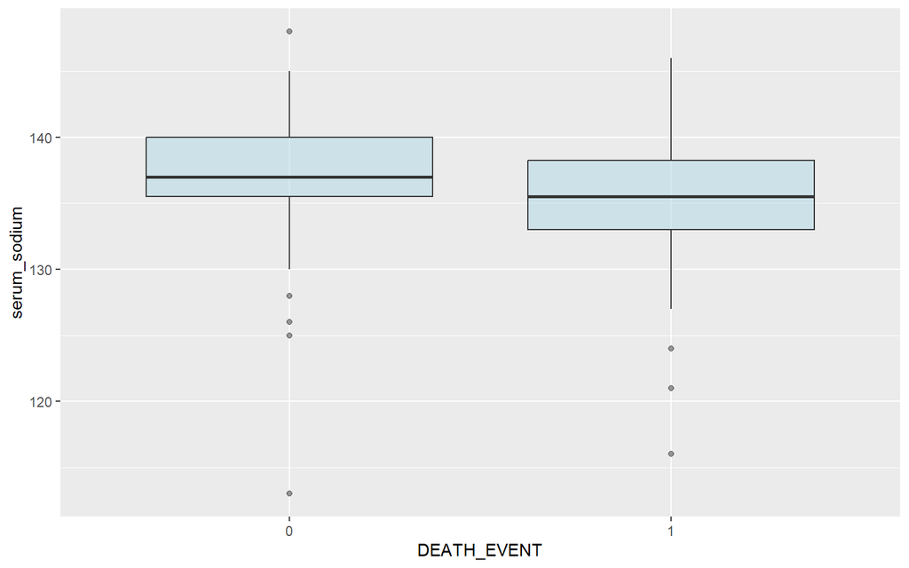

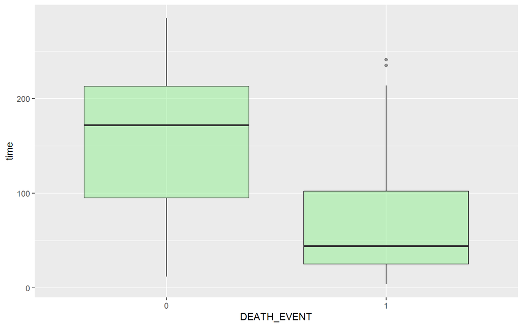

```r
lst <- list(age = data$age, ejection_fraction = data$ejection_fraction,
            serum_creatinine = data$serum_creatinine, serum_sodium = data$serum_sodium, time = data$time)
lstcolor <- list('red', 'blue', 'purple', 'lightblue', 'lightgreen')
n = 1
for (i in lst) {
  print(ggplot(data) +
          geom_boxplot(aes(DEATH_EVENT, i), fill = lstcolor[n], alpha = 0.5) +
          ylab(label = names(lst)[n]))
  n = n + 1
}
```

# 5 Data preprocessing

```r
# Split the data into training and testing sets
set.seed(1)
train <- sample(1:nrow(data), 210)
train_data <- data[train,]
test_data <- data[-train,]
```

# 6 Train models and make predictions

Now, we are going to create some models and check the performance measures.

## 6.1 Train models

### 6.1.1 SVM (Support vector machine)

```r
svm_model <- ksvm(DEATH_EVENT ~ ., data = train_data, kernel = 'vanilladot') # linear kernel
svm_model
```

```
## Support Vector Machine object of class "ksvm"
##
## SV type: C-svc  (classification)
##  parameter : cost C = 1
##
## Linear (vanilla) kernel function.
##
## Number of Support Vectors : 94
##
## Objective Function Value : -86.941
## Training error : 0.161905
```

```r
svm_pred <- predict(svm_model, test_data)
table(svm_pred, test_data$DEATH_EVENT)
```

```
##
## svm_pred  0  1
##        0 56  5
##        1  5 23
```

```r
agree <- svm_pred == test_data$DEATH_EVENT
svm_acc <- prop.table(table(agree)) # accuracy
svm_acc
```

```
## agree
##     FALSE      TRUE
## 0.1123596 0.8876404
```

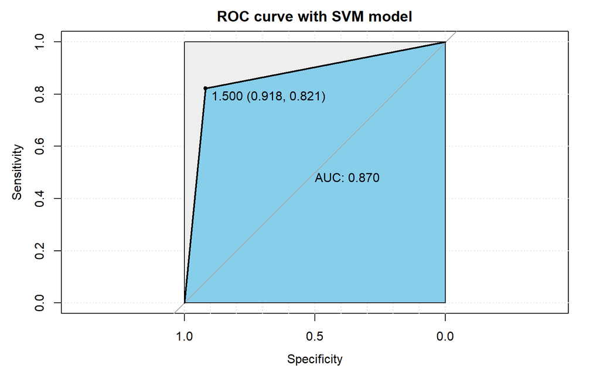

```r
svm_roc <- roc(test_data$DEATH_EVENT, as.numeric(svm_pred))
plot(svm_roc, print.auc = TRUE, auc.polygon = TRUE, grid = c(0.1, 0.2),
     auc.polygon.col = 'skyblue', max.auc.polygon = TRUE, print.thres = TRUE, main = 'ROC curve with SVM model')
```

```r
# Additional metrics using caret package
svm_precision <- posPredValue(as.factor(svm_pred), as.factor(test_data$DEATH_EVENT))
svm_recall <- sensitivity(as.factor(svm_pred), as.factor(test_data$DEATH_EVENT))
# AUC using pROC package
svm_roc <- roc(as.factor(test_data$DEATH_EVENT), as.numeric(svm_pred))
svm_auc <- auc(svm_roc)
# Display SVM model results
cat("Support Vector Machines (SVM) Accuracy:", svm_acc, "\n")
```

```
## Support Vector Machines (SVM) Accuracy: 0.1123596 0.8876404
```

```r
cat("Support Vector Machines (SVM) Precision:", svm_precision, "\n")
```

```
## Support Vector Machines (SVM) Precision: 0.9180328
```

```r
cat("Support Vector Machines (SVM) Recall:", svm_recall, "\n")
```

```
## Support Vector Machines (SVM) Recall: 0.9180328
```

```r
cat("Support Vector Machines (SVM) AUC:", svm_auc, "\n")
```

```
## Support Vector Machines (SVM) AUC: 0.8697307
```

### 6.1.2 Decision tree

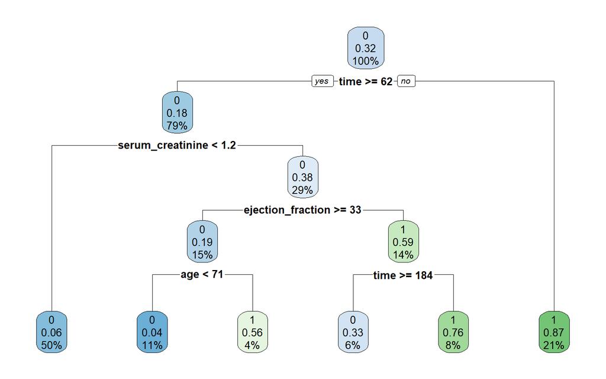

```r
# Decision Trees model
tree_model <- rpart(DEATH_EVENT ~ ., data = train_data)
rpart.plot(tree_model)
```

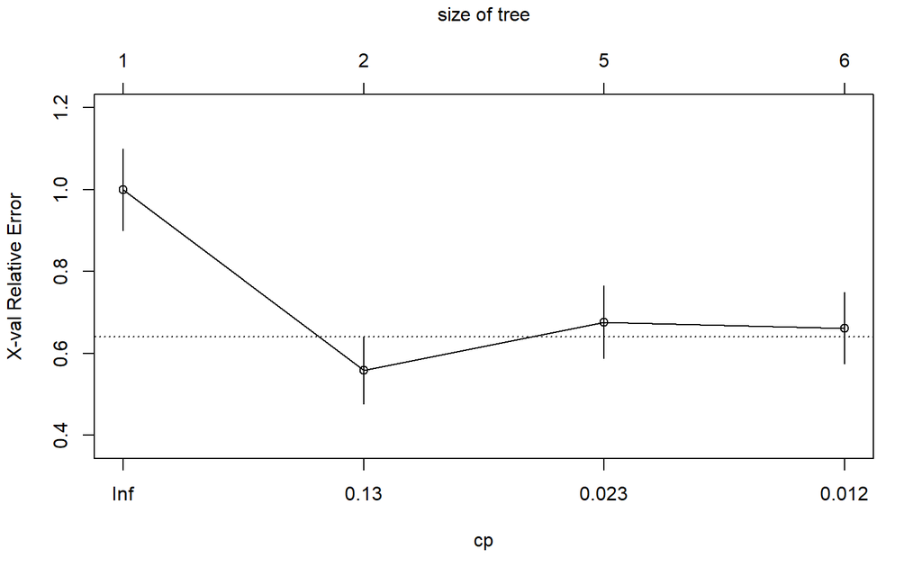

```r
tree_pred <- predict(tree_model, test_data, type = 'class')
plotcp(tree_model)
```

```r
dt_acc <- sum(diag(table(test_data$DEATH_EVENT, tree_pred))) / sum(table(test_data$DEATH_EVENT, tree_pred))
dt_acc
```

```
## [1] 0.8426966
```

```r
dt_roc <- roc(test_data$DEATH_EVENT, as.numeric(tree_pred))
```

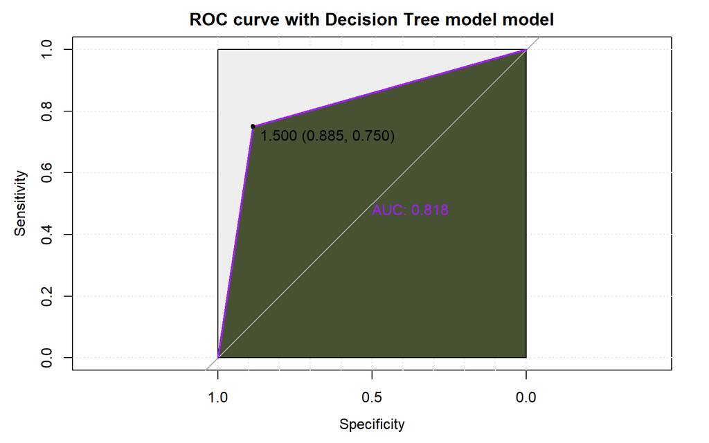

```r
generate_random_color <- function() {
  paste0("#", paste0(sample(0:9, 6, replace = TRUE), collapse = ""))
}
plot(dt_roc, print.auc = TRUE, auc.polygon = TRUE, grid = c(0.1, 0.2),
      auc.polygon.col = generate_random_color(), max.auc.polygon = TRUE, print.thres = TRUE, col = "purple", main = 'ROC curve with Decision Tree model model')
```

```r
# Additional metrics using caret package
tree_precision <- posPredValue(as.factor(tree_pred), as.factor(test_data$DEATH_EVENT))
tree_recall <- sensitivity(as.factor(tree_pred), as.factor(test_data$DEATH_EVENT))
tree_roc <- roc(as.factor(test_data$DEATH_EVENT), as.numeric(tree_pred))
tree_auc <- auc(tree_roc)
# Display Decision Trees model results
cat("Decision Trees Accuracy:", dt_acc, "\n")
```

```
## Decision Trees Accuracy: 0.8426966
```

```r
cat("Decision Trees Precision:", tree_precision, "\n")
```

```
## Decision Trees Precision: 0.8852459
```

```r
cat("Decision Trees Recall:", tree_recall, "\n")
```

```
## Decision Trees Recall: 0.8852459
```

```r
cat("Decision Trees AUC:", tree_auc, "\n")
```

```
## Decision Trees AUC: 0.817623
```

### 6.1.3 K-Nearest Neighbors (kNN) model

```r
# k-Nearest Neighbors (kNN) model
train_data_label <- as.factor(train_data$DEATH_EVENT)
train_data_knn <- scale(train_data[1:12])
test_data_label <- as.factor(test_data$DEATH_EVENT)
test_data_knn <- scale(test_data[1:12])
knn_pred <- knn(train = train_data_knn, test = test_data_knn, cl = train_data_label, k = 13)
CrossTable(x = test_data_label, y = knn_pred, prop.chisq = FALSE)
```

```
##
##
##    Cell Contents
## |-------------------------|
## |                       N |
## |           N / Row Total |
## |           N / Col Total |
## |         N / Table Total |
## |-------------------------|
##
##
## Total Observations in Table:  89
##
##
##                 | knn_pred
## test_data_label |         0 |         1 | Row Total |
## ----------------|-----------|-----------|-----------|
##               0 |        58 |         3 |        61 |
##                 |     0.951 |     0.049 |     0.685 |
##                 |     0.744 |     0.273 |           |
##                 |     0.652 |     0.034 |           |
## ----------------|-----------|-----------|-----------|
##               1 |        20 |         8 |        28 |
##                 |     0.714 |     0.286 |     0.315 |
##                 |     0.256 |     0.727 |           |
##                 |     0.225 |     0.090 |           |
## ----------------|-----------|-----------|-----------|
##    Column Total |        78 |        11 |        89 |
##                 |     0.876 |     0.124 |           |
## ----------------|-----------|-----------|-----------|
##
##
```

```r
knn_acc <- sum(test_data_label == knn_pred) / length(test_data_label)
knn_acc
```

```
## [1] 0.741573
```

```r
knn_roc <- roc(test_data$DEATH_EVENT, as.numeric(knn_pred))
```

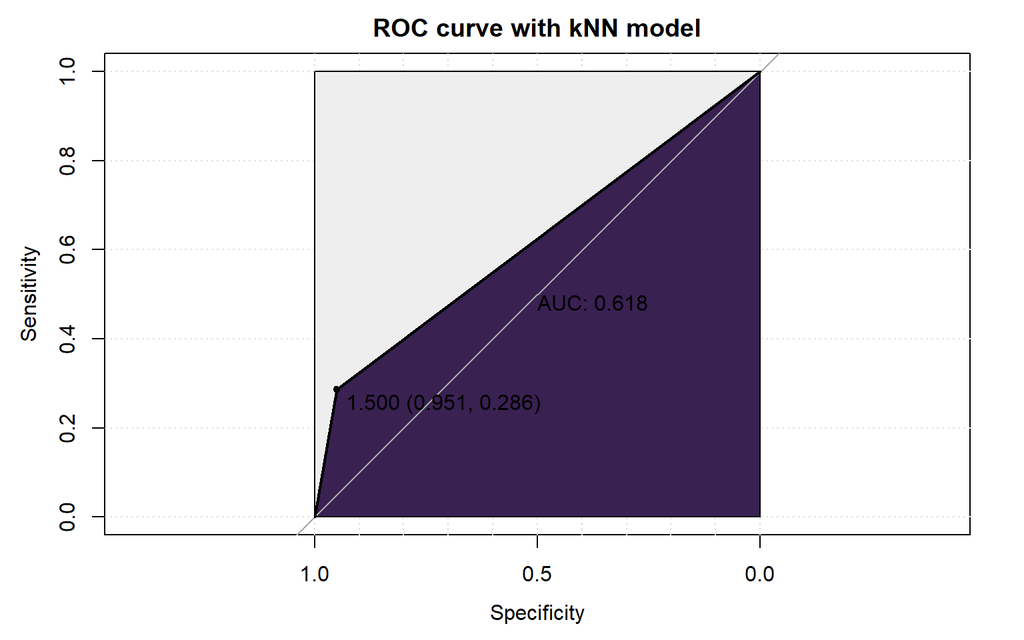

```r
# Plot ROC curve for kNN model with a random color
plot(knn_roc, print.auc = TRUE, auc.polygon = TRUE, grid = c(0.1, 0.2),
     auc.polygon.col = generate_random_color(), max.auc.polygon = TRUE, print.thres = TRUE, main = 'ROC curve with kNN model')
```

```r
# Additional metrics using caret package
knn_precision <- posPredValue(as.factor(knn_pred), as.factor(test_data$DEATH_EVENT))
knn_recall <- sensitivity(as.factor(knn_pred), as.factor(test_data$DEATH_EVENT))
# AUC using pROC package
knn_roc <- roc(as.factor(test_data$DEATH_EVENT), as.numeric(knn_pred))
knn_auc <- auc(knn_roc)
# Display kNN model results
cat("k-Nearest Neighbors (kNN) Accuracy:", knn_acc, "\n")
```

```
## k-Nearest Neighbors (kNN) Accuracy: 0.741573
```

```r
cat("k-Nearest Neighbors (kNN) Precision:", knn_precision, "\n")
```

```
## k-Nearest Neighbors (kNN) Precision: 0.7435897
```

```r
cat("k-Nearest Neighbors (kNN) Recall:", knn_recall, "\n")
```

```
## k-Nearest Neighbors (kNN) Recall: 0.9508197
```

```r
cat("k-Nearest Neighbors (kNN) AUC:", knn_auc, "\n")
```

```
## k-Nearest Neighbors (kNN) AUC: 0.618267
```

### 6.1.4 Logistic Regression model

```r
# Logistic Regression model
logistic_model <- glm(DEATH_EVENT ~ ., data = train_data, family = "binomial")
logistic_pred_prob <- predict(logistic_model, test_data, type = 'response')
logistic_pred <- ifelse(logistic_pred_prob > 0.5, 1, 0)

# Evaluate Logistic Regression model
logistic_cM <- confusionMatrix(as.factor(logistic_pred), as.factor(test_data$DEATH_EVENT))
logistic_acc <- sum(diag(logistic_cM$table)) / sum(logistic_cM$table)
logistic_roc <- roc(test_data$DEATH_EVENT, logistic_pred_prob)
# Display Logistic Regression model results
cat("Logistic Regression Accuracy:", logistic_acc, "\n")
```

```
## Logistic Regression Accuracy: 0.8988764
```

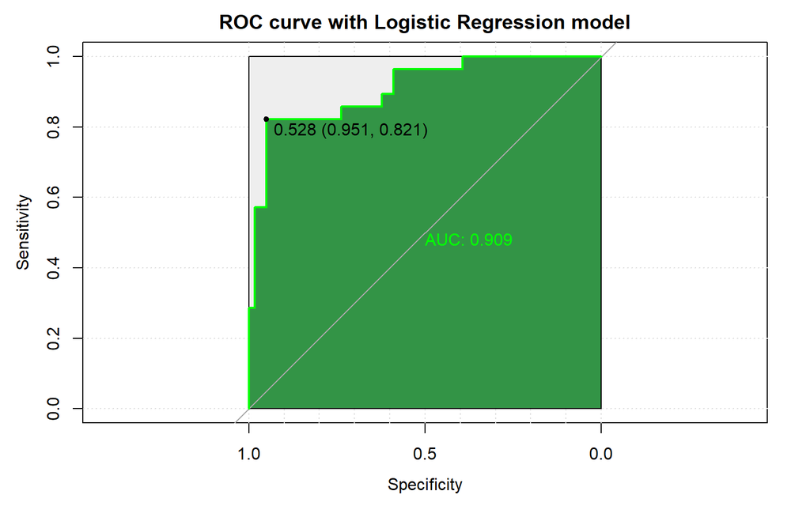

```r
plot(logistic_roc, print.auc = TRUE, auc.polygon = TRUE, grid = c(0.1, 0.2),
     auc.polygon.col = generate_random_color(), max.auc.polygon = TRUE, print.thres = TRUE, col = "green", main = 'ROC curve with Logistic Regression model')
```

```r
# Additional metrics using caret package
logistic_precision <- posPredValue(as.factor(logistic_pred), as.factor(test_data$DEATH_EVENT))
logistic_recall <- sensitivity(as.factor(logistic_pred), as.factor(test_data$DEATH_EVENT))
logistic_roc <- roc(as.factor(test_data$DEATH_EVENT), logistic_pred_prob)
logistic_auc <- auc(logistic_roc)
# Display Logistic Regression model results
cat("Logistic Regression Accuracy:", logistic_acc, "\n")
```

```
## Logistic Regression Accuracy: 0.8988764
```

```r
cat("Logistic Regression Precision:", logistic_precision, "\n")
```

```
## Logistic Regression Precision: 0.9193548
```

```r
cat("Logistic Regression Recall:", logistic_recall, "\n")
```

```
## Logistic Regression Recall: 0.9344262
```

```r
cat("Logistic Regression AUC:", logistic_auc, "\n")
```

```
## Logistic Regression AUC: 0.9092506
```

### 6.1.5 Random Forest model

```r
# Random Forest model
rf_model <- randomForest(DEATH_EVENT ~ ., data = train_data)
rf_pred <- predict(rf_model, test_data)
# Confusion Matrix
rf_cM <- confusionMatrix(as.factor(rf_pred), as.factor(test_data$DEATH_EVENT))
# Accuracy
rf_acc <- sum(diag(rf_cM$table)) / sum(rf_cM$table)
# Additional metrics using caret package
rf_precision <- posPredValue(as.factor(rf_pred), as.factor(test_data$DEATH_EVENT))
rf_recall <- sensitivity(as.factor(rf_pred), as.factor(test_data$DEATH_EVENT))
# AUC using pROC package
rf_roc <- roc(as.factor(test_data$DEATH_EVENT), as.numeric(rf_pred))
rf_auc <- auc(rf_roc)
# Display Random Forest model results
cat("Random Forest Accuracy:", rf_acc, "\n")
```

```
## Random Forest Accuracy: 0.8764045
```

```r
cat("Random Forest Precision:", rf_precision, "\n")
```

```
## Random Forest Precision: 0.890625
```

```r
cat("Random Forest Recall:", rf_recall, "\n")
```

```
## Random Forest Recall: 0.9344262
```

```r
cat("Random Forest AUC:", rf_auc, "\n")
```

```
## Random Forest AUC: 0.8422131
```

```r
# Visualize OOB error rate for Random Forest
oob.err.data <- data.frame(
  Trees = rep(1:nrow(rf_model$err.rate), 3),
  Type = rep(c("OOB", "Not Death", "Death"), each = nrow(rf_model$err.rate)),
  Error = c(rf_model$err.rate[,"OOB"], rf_model$err.rate[,"0"], rf_model$err.rate[,"1"])
)
round(importance(rf_model), 2)
```

```
##                          MeanDecreaseGini
## age                                  9.82
## anaemia                              1.19
## creatinine_phosphokinase             6.94
## diabetes                             1.27
## ejection_fraction                    9.25
## high_blood_pressure                  1.32
## platelets                            8.00
## serum_creatinine                    13.78
## serum_sodium                         7.55
## sex                                  1.05
## smoking                              1.19
## time                                29.91
```

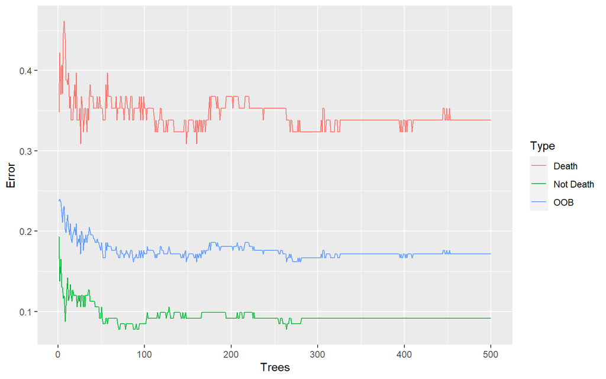

```r
ggplot(data = oob.err.data, aes(x = Trees, y = Error)) + geom_line(aes(color = Type))
```